# Test a Perceptual Phenomenon

### Analyzing the Stroop Effect

In a Stroop task, participants are presented with a list of words, with each word displayed in a color of ink. The participant’s task is to say out loud the color of the ink in which the word is printed. The task has two conditions: a congruent words condition, and an incongruent words condition. In the congruent words condition, the words being displayed are color words whose names match the colors in which they are printed: for example RED, BLUE. In the incongruent words condition, the words displayed are color words whose names do not match the colors in which they are printed: for example PURPLE, ORANGE. In each case, we measure the time it takes to name the ink colors in equally-sized lists. Each participant will go through and record a time from each condition.

### In this project we use descriptive statistics and a statistical test to analyze the Stroop effect, a classic result of experimental psychology.

(1) What is the independent variable? What is the dependent variable?

The condition (congruent or incongruent) is the independant variable

The recorded time is the dependant variable

(2) What is an appropriate set of hypotheses for this task? Specify your null and alternative hypotheses, and clearly define any notation used. Justify your choices.

$H_0:$ $\mu_{cong}-\mu_{incong}=0$

$H_1:$ $\mu_{cong}-\mu_{incong}\neq 0$

$\mu_{cong}$ stands for average time spent in congruent condition

$\mu_{incong}$ stands for average time spent in incongruent condition

##### We'll perform a two tailed t-test to compare the mean time of the two dependant samples we have, the threshold we'll use is $\alpha=0.05$

##### I see that the t-test is more adapted than a z-test because we don't have any standard deviation of the population and in the z-tests we don't generally look to compare two paired samples, also the sample size is less than 30

(3) Report some descriptive statistics regarding this dataset. Include at least one measure of central tendency and at least one measure of variability. The name of the data file is 'stroopdata.csv'.

```python
# Perform the analysis here
```

```python
import pandas as pd
from numpy import sqrt, std
df=pd.read_csv('stroopdata.csv')
df.head()
```

|  | Congruent | Incongruent |
| --- | --- | --- |
| 0 | 12.079 | 19.278 |
| 1 | 16.791 | 18.741 |
| 2 | 9.564 | 21.214 |
| 3 | 8.630 | 15.687 |
| 4 | 14.669 | 22.803 |

```python
df['Congruent'].mean()
```

```
14.051125000000004
```

```python
df['Incongruent'].mean()
```

```
22.01591666666667
```

```python
df['Congruent'].std()
```

```
3.559357957645195
```

```python
df['Incongruent'].std()
```

```
4.797057122469138
```

(4) Provide one or two visualizations that show the distribution of the sample data. Write one or two sentences noting what you observe about the plot or plots.

```python
# Build the visualizations here
```

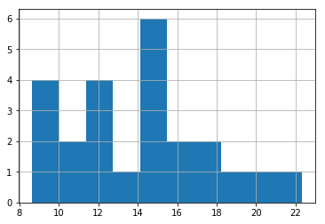

```python
df['Congruent'].hist();
```

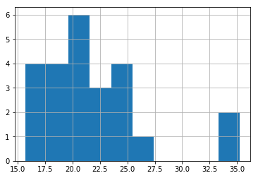

```python
df['Incongruent'].hist();
```

From the preceeding plots we observe that there are some outliers, and that the means are quite different.

(5) Now, perform the statistical test and report your results. What is your confidence level or Type I error associated with your test? What is your conclusion regarding the hypotheses you set up? Did the results match up with your expectations? **Hint:** Think about what is being measured on each individual, and what statistic best captures how an individual reacts in each environment.

```python
# Perform the statistical test here
```

1/ Calculate the means of the difference between the two samples, noted mt

```python
df['diff']=df['Congruent']-df['Incongruent']
mt=df['diff'].mean()
```

[output not shown]

2/ Calculate the Standard Deviation of the difference

```python
ss=((df['diff']-mt)**2).sum()
SD=(sqrt(ss/(df.shape[0]-1)))
SD
```

```
4.864826910359056
```

3/ calcuate the t-value and pool the t-critical value from the t-table

```python
t=mt/(SD/sqrt(df.shape[0]))
print('The t-value of this two-tailed test is'.format(),t)
```

```
The t-value of this two-tailed test is -8.020706944109957
```

```python
print('The t-critical for an alpha-level of 0.05 and 23 Degrees of freedom is +-'.format(),2.064)
```

```
The t-critical for an alpha-level of 0.05 and 23 Degrees of freedom is +- 2.064
```